# Student Performance Analytics: Regression Modelling

- Show All Code
- Hide All Code
- View Source

Explaining GPA Through Behavioural and Educational Factors

Author

Md Soad Solaiman

## 1 Executive Summary

This report examines statistical associations between student characteristics and GPA using simple and multiple linear regression. Two simple models evaluate weekly study time and absences separately. A multiple regression model then combines study time, absences, tutoring, parental support, and extracurricular participation.

Weekly study time has a positive but weak in-sample association with GPA. The model explains approximately **3.2%** of observed GPA variation. Absences have a much stronger negative association with GPA, explaining approximately **84.5%** of observed variation in the corresponding simple model.

The multiple regression model has the strongest in-sample fit of the three reported specifications, with an adjusted (R^2) of approximately **0.941** and a residual standard error of approximately **0.223**. This comparison describes explanatory performance on the data used to fit the models. It does not establish causal relationships or demonstrate predictive accuracy for new students because no train/test split, cross-validation, or external validation was performed.

## 2 Analytical Objective

The objective is to quantify associations between selected student characteristics and GPA, compare simple regression specifications, and evaluate a multivariable model that adjusts each coefficient for the remaining included predictors.

All analyses use the repository dataset at `data/student-performance-data.csv`. Statistical significance is assessed at the **5% level**. The response variable is GPA, measured on a bounded scale from 0 to 4.

### 2.1 Analysis Setup

**Show R code**

```r
knitr::opts_chunk$set(warning = FALSE, message = FALSE)
```

**Show R code**

```r
library(tidyverse)
library(broom)
library(knitr)
library(kableExtra)
library(car)
library(performance)

portfolio_navy <- "#17324D"
portfolio_blue <- "#2563A6"
portfolio_teal <- "#0F766E"
portfolio_orange <- "#C65D21"
portfolio_purple <- "#6D5A9E"
portfolio_panel <- function(x, y, ...) {
  panel.smooth(x, y, col.smooth = portfolio_orange, ...)
}

theme_set(
  theme_minimal(base_size = 12) +
    theme(
      plot.title = element_text(face = "bold", colour = portfolio_navy),
      plot.subtitle = element_text(colour = "#5F6F7F"),
      axis.title = element_text(face = "bold", colour = portfolio_navy),
      panel.grid.minor = element_blank(),
      panel.grid.major = element_line(colour = "#E5EBF0", linewidth = 0.35),
      legend.position = "bottom",
      plot.margin = margin(10, 14, 10, 10)
    )
)
```

**Show R code**

```r
student_data <- read.csv("data/student-performance-data.csv")
```

## 3 Simple Regression: Weekly Study Time

### 3.1 Descriptive Evidence

The first model evaluates the linear association between weekly study time and GPA.

**Show R code**

```r
study_gpa_data <- student_data %>%
  select(StudyTimeWeekly, GPA) %>%
  drop_na()

study_summary <- study_gpa_data %>%
  summarise(
    Mean_Study_Hours = round(mean(StudyTimeWeekly), 2),
    SD_Study_Hours   = round(sd(StudyTimeWeekly), 2),
    Mean_GPA         = round(mean(GPA), 2),
    SD_GPA           = round(sd(GPA), 2),
    Correlation      = round(cor(StudyTimeWeekly, GPA), 2)
  )

study_summary %>%
  kable(
    caption = "Summary Statistics for Weekly Study Time and GPA",
    align   = "c",
    col.names = c("Mean Study Hours", "SD Study Hours", "Mean GPA", "SD GPA", "Correlation")
  ) %>%
  kable_styling(
    full_width = FALSE,
    position   = "center"
  )
```

Summary Statistics for Weekly Study Time and GPA

| Mean Study Hours | SD Study Hours | Mean GPA | SD GPA | Correlation |
| --- | --- | --- | --- | --- |
| 9.77 | 5.65 | 1.91 | 0.92 | 0.18 |

Weekly study time ranges from approximately 0 to 20 hours, with a mean of about **9.8 hours**. Mean GPA is approximately **1.91**. The correlation of approximately **0.18** indicates a weak positive linear association.

**Show R code**

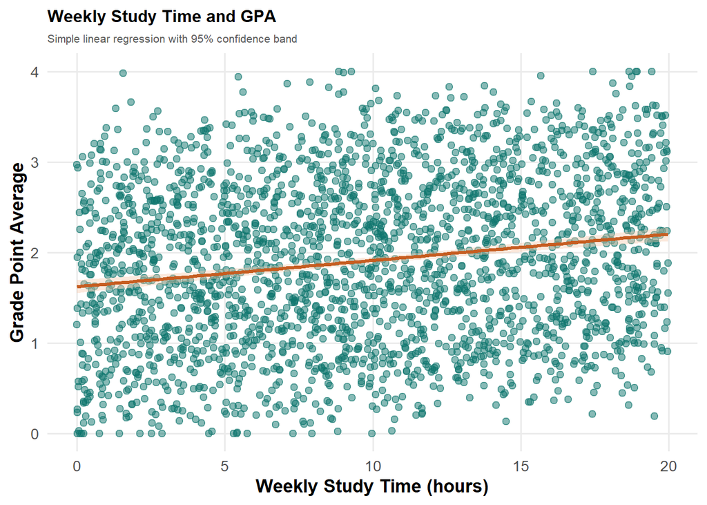

Figure 1: Observed GPA by weekly study time with a fitted simple regression line and 95% confidence band.

```r
ggplot(study_gpa_data, aes(x = StudyTimeWeekly, y = GPA)) +
  geom_point(alpha = 0.5, size = 2.1, colour = portfolio_teal) +
  geom_smooth(method = "lm", se = TRUE,
              colour = portfolio_orange, fill = "#F6C7AA", linewidth = 1.2) +
  labs(
    title    = "Weekly Study Time and GPA",
    subtitle = "Simple linear regression with 95% confidence band",
    x = "Weekly Study Time (hours)",
    y = "Grade Point Average"
  ) +
  theme_minimal(base_size = 13) +
  theme(
    plot.title       = element_text(face = "bold", size = 12),
    plot.subtitle    = element_text(size = 8, colour = "gray35"),
    axis.title       = element_text(face = "bold"),
    panel.grid.minor = element_blank()
  )
```

The wide scatter around the fitted line shows that weekly study time alone accounts for a limited proportion of GPA variation.

### 3.2 Model Fit and Interpretation

**Show R code**

```r
study_model <- lm(GPA ~ StudyTimeWeekly, data = study_gpa_data)
summary(study_model)
```

```
Call:
lm(formula = GPA ~ StudyTimeWeekly, data = study_gpa_data)

Residuals:
     Min       1Q   Median       3Q      Max
-1.99922 -0.73441 -0.00121  0.72442  2.31142

Coefficients:
                Estimate Std. Error t value Pr(>|t|)
(Intercept)     1.622567   0.036777  44.119   <2e-16 ***
StudyTimeWeekly 0.029024   0.003258   8.909   <2e-16 ***
---
Signif. codes:  0 '***' 0.001 '**' 0.01 '*' 0.05 '.' 0.1 ' ' 1

Residual standard error: 0.9005 on 2390 degrees of freedom
Multiple R-squared:  0.03214,   Adjusted R-squared:  0.03173
F-statistic: 79.36 on 1 and 2390 DF,  p-value: < 2.2e-16
```

The fitted model is:

$$\widehat{\text{GPA}} = 1.623 + 0.029 \times \text{StudyTimeWeekly}$$

The estimated study-time coefficient is **0.029024** with (p<2^{-16}). Within this sample, each additional weekly study hour is associated with an average GPA difference of approximately **+0.029 points**. The intercept of **1.622567** is the fitted GPA at zero weekly study hours.

The model has (R^2=0.03214), adjusted (R^2=0.03173), and residual standard error **0.9005**. Weekly study time therefore explains approximately **3.2%** of the observed GPA variation in sample. The association is statistically significant, but the model has limited standalone explanatory performance.

### 3.3 Diagnostic Evidence

**Show R code**

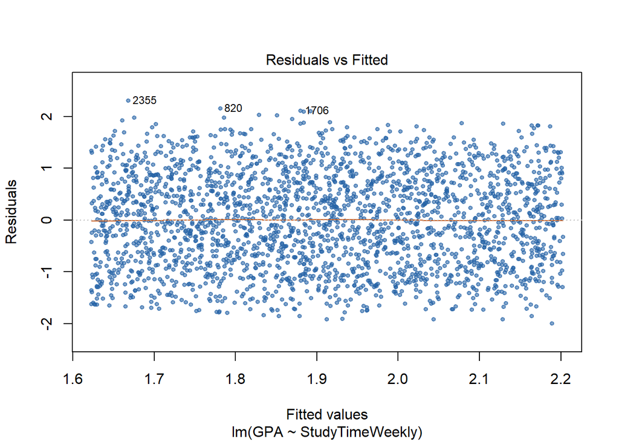

Figure 2: Residuals versus fitted values for the weekly study-time model.

```r
plot(study_model, which = 1,
     col = adjustcolor(portfolio_blue, alpha.f = 0.58),
     panel = portfolio_panel,
     pch = 19, cex = 0.65, id.n = 3)
```

The residual smoother is broadly horizontal, which is consistent with an approximately linear mean relationship. Minor structure may remain.

**Show R code**

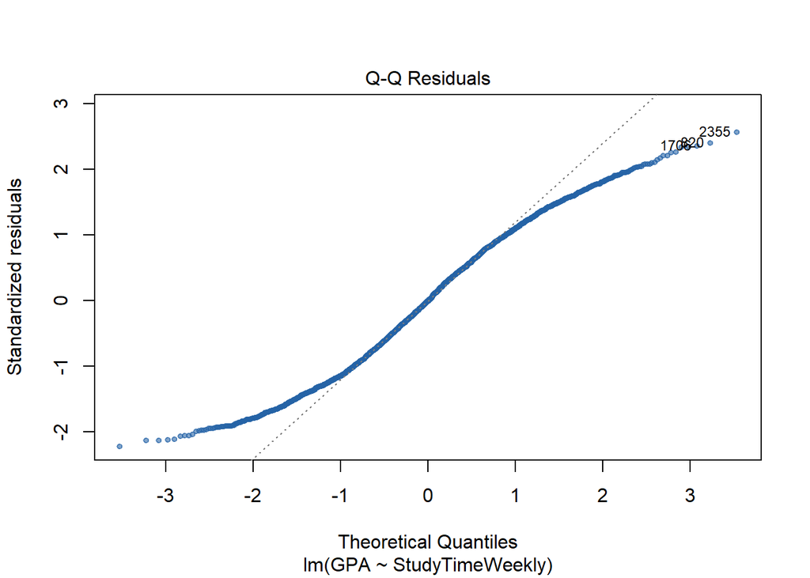

Figure 3: Normal Q-Q plot of residuals from the weekly study-time model.

```r
plot(study_model, which = 2,
     col = adjustcolor(portfolio_blue, alpha.f = 0.58),
     panel = portfolio_panel,
     pch = 19, cex = 0.65, id.n = 3)
```

Residuals follow the reference line through the centre and depart in both tails. The diagnostic supports approximate rather than exact residual Normality.

**Show R code**

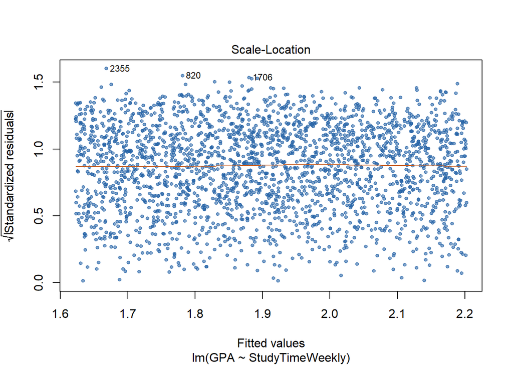

Figure 4: Scale-location diagnostic for the weekly study-time model.

```r
plot(study_model, which = 3,
     col = adjustcolor(portfolio_blue, alpha.f = 0.58),
     panel = portfolio_panel,
     pch = 19, cex = 0.65, id.n = 3)
```

**Show R code**

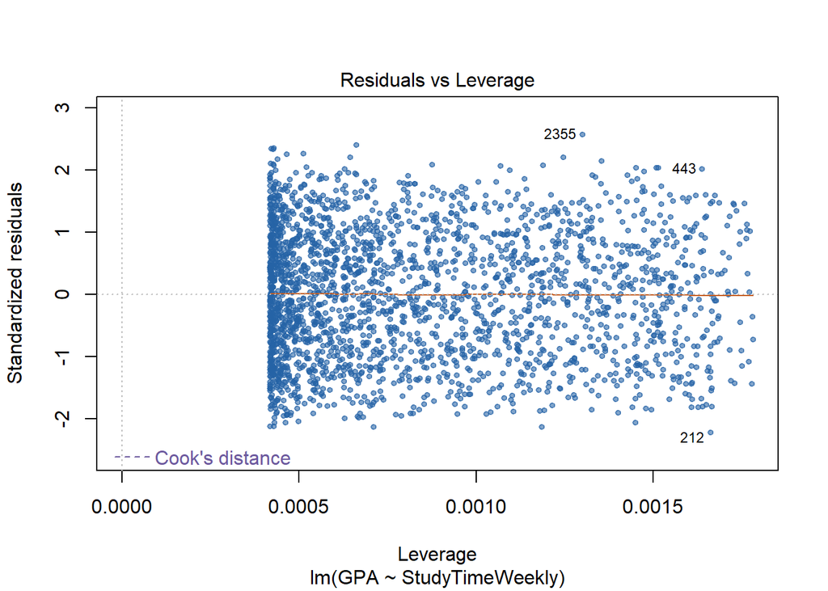

Figure 5: Residuals versus leverage for the weekly study-time model.

```r
plot(study_model, which = 5,
     col = adjustcolor(portfolio_blue, alpha.f = 0.58),
     panel = portfolio_panel,
     cook.col = portfolio_purple,
     pch = 19, cex = 0.65, id.n = 3)
```

No observations are displayed beyond the Cook’s-distance contours. This suggests that no single record dominates the fitted model under this diagnostic, although influence should not be considered impossible solely from the plot.

Observational independence cannot be verified from the dataset alone because the sampling and collection process is not documented. It is adopted as a modelling assumption.

## 4 Simple Regression: Absences

### 4.1 Descriptive Evidence

The second model evaluates the linear association between the number of absences and GPA.

**Show R code**

```r
absence_gpa_data <- student_data %>%
  select(Absences, GPA) %>%
  drop_na()

absence_summary <- absence_gpa_data %>%
  summarise(
    Mean_Absences = round(mean(Absences), 2),
    SD_Absences = round(sd(Absences), 2),
    Mean_GPA = round(mean(GPA), 2),
    SD_GPA = round(sd(GPA), 2),
    Correlation = round(cor(Absences, GPA), 2)
  )

absence_summary %>%
  kable(
    caption = "Summary Statistics for Absences and GPA",
    align = "c",
    col.names = c("Mean Absences", "SD Absences", "Mean GPA", "SD GPA", "Correlation")
  ) %>%
  kable_styling(
    full_width = FALSE,
    position = "center"
  )
```

Summary Statistics for Absences and GPA

| Mean Absences | SD Absences | Mean GPA | SD GPA | Correlation |
| --- | --- | --- | --- | --- |
| 14.54 | 8.47 | 1.91 | 0.92 | -0.92 |

**Show R code**

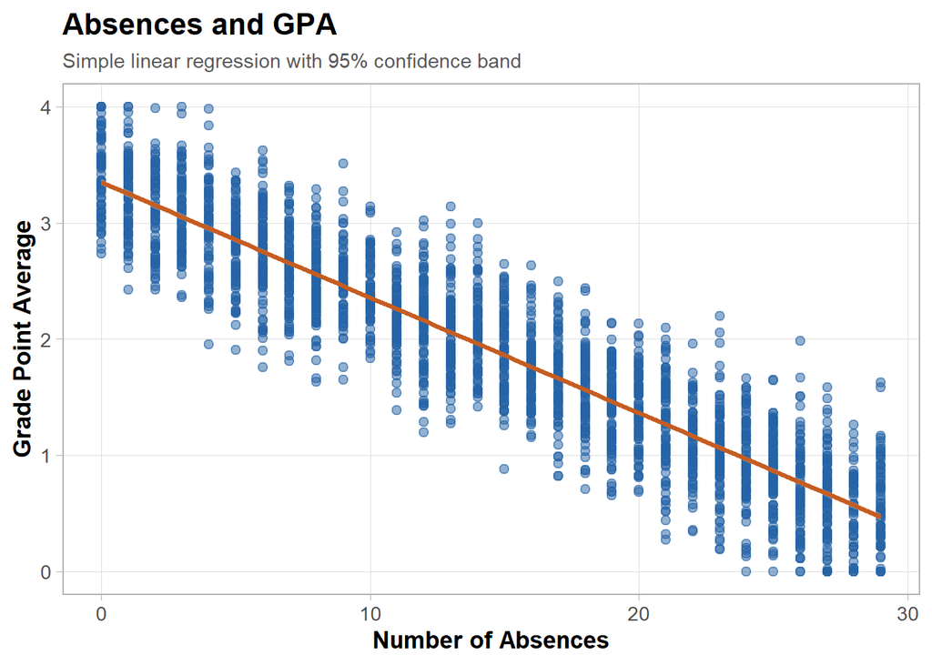

Figure 6: Observed GPA by number of absences with a fitted simple regression line and 95% confidence band.

```r
ggplot(absence_gpa_data, aes(x = Absences, y = GPA)) +
  geom_point(alpha = 0.5, size = 2.1, colour = portfolio_blue) +
  geom_smooth(method = "lm", se = TRUE,
              colour = portfolio_orange, fill = "#F6C7AA", linewidth = 1.2) +
  labs(
    title    = "Absences and GPA",
    subtitle = "Simple linear regression with 95% confidence band",
    x = "Number of Absences",
    y = "Grade Point Average"
  ) +
  theme_light(base_size = 13) +
  theme(
    plot.title       = element_text(face = "bold", size = 16),
    plot.subtitle    = element_text(size = 11, colour = "gray35"),
    axis.title       = element_text(face = "bold"),
    panel.grid.minor = element_blank()
  )
```

The plot shows a strong negative linear association. The correlation is approximately **−0.92**, and observations lie substantially closer to the fitted line than in the study-time model.

### 4.2 Model Fit and Interpretation

**Show R code**

```r
absence_model <- lm(GPA ~ Absences, data = absence_gpa_data)
summary(absence_model)
```

```
Call:
lm(formula = GPA ~ Absences, data = absence_gpa_data)

Residuals:
     Min       1Q   Median       3Q      Max
-1.00037 -0.25727  0.01052  0.24920  1.21547

Coefficients:
            Estimate Std. Error t value Pr(>|t|)
(Intercept)  3.35101    0.01464   228.9   <2e-16 ***
Absences    -0.09936    0.00087  -114.2   <2e-16 ***
---
Signif. codes:  0 '***' 0.001 '**' 0.01 '*' 0.05 '.' 0.1 ' ' 1

Residual standard error: 0.3602 on 2390 degrees of freedom
Multiple R-squared:  0.8451,    Adjusted R-squared:  0.8451
F-statistic: 1.304e+04 on 1 and 2390 DF,  p-value: < 2.2e-16
```

The fitted model is:

$$\widehat{\text{GPA}} = 3.351 - 0.099 \times \text{Absences}$$

The estimated absence coefficient is **−0.09936** with (p<2^{-16}). Within this sample, each additional absence is associated with an average GPA difference of approximately **−0.099 points**. Using the unrounded model coefficients, the fitted GPA is approximately **3.35** at zero absences and **0.37** at 30 absences.

The model has (R^2=0.8451), adjusted (R^2=0.8451), and residual standard error **0.3602**. Absences alone explain approximately **84.5%** of observed GPA variation in sample.

### 4.3 Diagnostic Evidence

**Show R code**

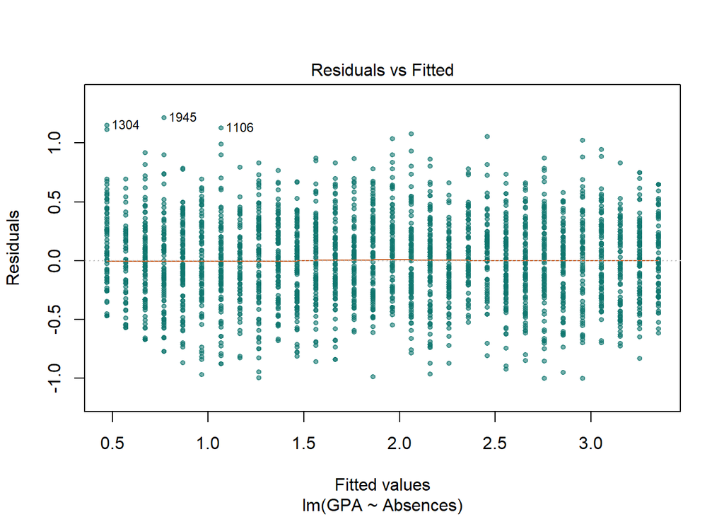

Figure 7: Residuals versus fitted values for the absences model.

```r
plot(absence_model, which = 1,
     col = adjustcolor(portfolio_teal, alpha.f = 0.58),
     panel = portfolio_panel,
     pch = 19, cex = 0.65, id.n = 3)
```

The residual smoother is broadly horizontal, supporting an approximately linear mean relationship.

**Show R code**

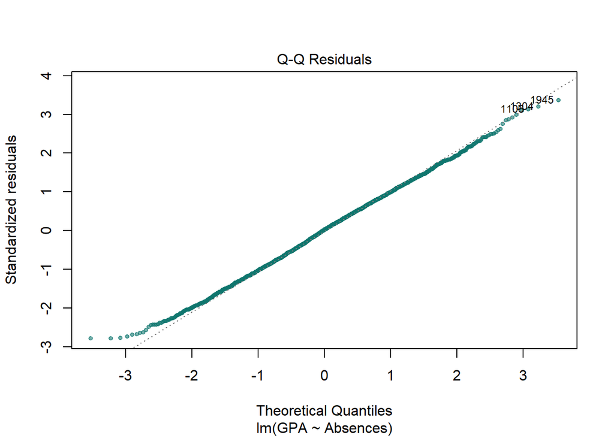

Figure 8: Normal Q-Q plot of residuals from the absences model.

```r
plot(absence_model, which = 2,
     col = adjustcolor(portfolio_teal, alpha.f = 0.58),
     panel = portfolio_panel,
     pch = 19, cex = 0.65, id.n = 3)
```

Residuals follow the reference line through most of the distribution, with some tail departures.

**Show R code**

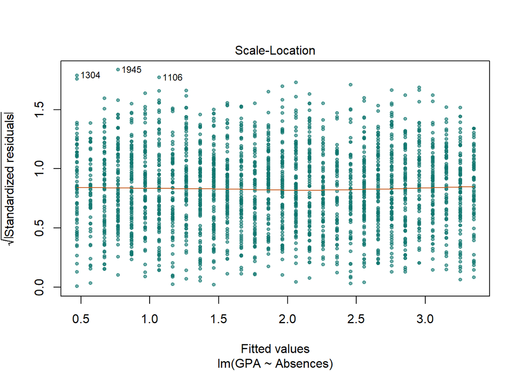

Figure 9: Scale-location diagnostic for the absences model.

```r
plot(absence_model, which = 3,
     col = adjustcolor(portfolio_teal, alpha.f = 0.58),
     panel = portfolio_panel,
     pch = 19, cex = 0.65, id.n = 3)
```

The scale-location plot indicates a relatively stable spread across fitted values, while small departures remain possible.

**Show R code**

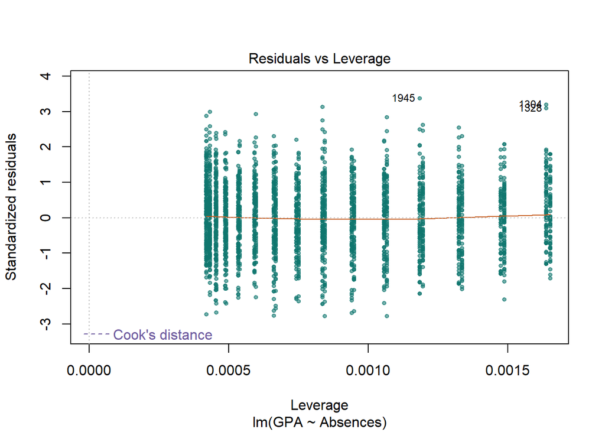

Figure 10: Residuals versus leverage for the absences model.

```r
plot(absence_model, which = 5,
     col = adjustcolor(portfolio_teal, alpha.f = 0.58),
     panel = portfolio_panel,
     cook.col = portfolio_purple,
     pch = 19, cex = 0.65, id.n = 3)
```

No observations are displayed beyond the Cook’s-distance boundaries. As with the study-time model, observational independence is assumed but cannot be verified from the dataset alone.

## 5 Model Comparison

The two simple regressions are compared using their visual fit, in-sample fit statistics, and diagnostic behaviour.

### 5.1 Visual Comparison

**Show R code**

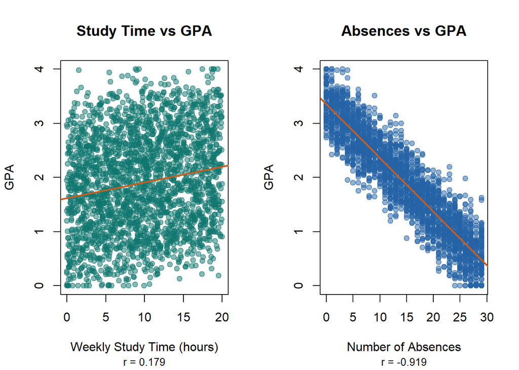

Figure 11: Side-by-side comparison of the weekly study-time and absences simple regression relationships.

```r
study_correlation   <- cor(study_gpa_data$StudyTimeWeekly, study_gpa_data$GPA)
absence_correlation <- cor(absence_gpa_data$Absences, absence_gpa_data$GPA)

par(mfrow = c(1, 2))

plot(study_gpa_data$StudyTimeWeekly, study_gpa_data$GPA,
     main = "Study Time vs GPA",
     xlab = "Weekly Study Time (hours)", ylab = "GPA",
     pch = 19, col = adjustcolor(portfolio_teal, alpha.f = 0.5))
title(sub = paste0("r = ", round(study_correlation, 3)), cex.sub = 0.85)
abline(study_model, col = portfolio_orange, lwd = 2)

plot(absence_gpa_data$Absences, absence_gpa_data$GPA,
     main = "Absences vs GPA",
     xlab = "Number of Absences", ylab = "GPA",
     pch = 19, col = adjustcolor(portfolio_blue, alpha.f = 0.5))
title(sub = paste0("r = ", round(absence_correlation, 3)), cex.sub = 0.85)
abline(absence_model, col = portfolio_orange, lwd = 2)

par(mfrow = c(1, 1))
```

### 5.2 In-Sample Fit Statistics

**Show R code**

```r
study_model_comparison <- glance(study_model) %>%
  select(r.squared, adj.r.squared, sigma, p.value) %>%
  mutate(Model = "Study Time")

absence_model_comparison <- glance(absence_model) %>%
  select(r.squared, adj.r.squared, sigma, p.value) %>%
  mutate(Model = "Absences")

model_comparison_table <- bind_rows(
  study_model_comparison,
  absence_model_comparison
) %>%
  select(Model, r.squared, adj.r.squared, sigma, p.value) %>%
  rename(
    `R²`      = r.squared,
    `Adjusted R²` = adj.r.squared,
    `Residual SE` = sigma,
    `p-value` = p.value
  )

kable(model_comparison_table, digits = 3,
      caption = "In-Sample Fit: Study-Time and Absences Models") %>%
  kable_styling(full_width = FALSE)
```

In-Sample Fit: Study-Time and Absences Models

| Model | R² | Adjusted R² | Residual SE | p-value |
| --- | --- | --- | --- | --- |
| Study Time | 0.032 | 0.032 | 0.901 | 0 |
| Absences | 0.845 | 0.845 | 0.360 | 0 |

Both slopes are statistically significant at the 5% level. The absences model has substantially higher in-sample explanatory performance: (R^2=0.845) compared with (R^2=0.032), while its residual standard error is **0.360** compared with **0.901** for the study-time model.

Higher (R^2) and lower residual standard error indicate a closer fit to the analysed observations. They do not demonstrate better prediction for unseen students.

### 5.3 Comparative Diagnostics

**Show R code**

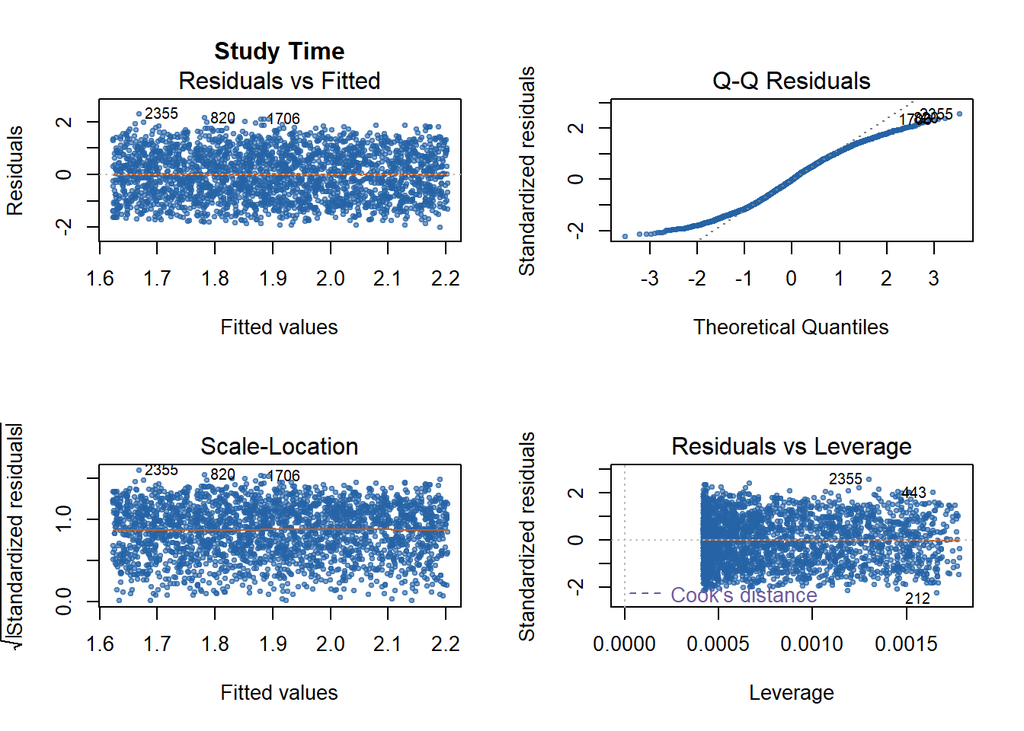

Figure 12: Combined diagnostic panel for the weekly study-time model.

```r
par(mfrow = c(2, 2))
plot(study_model, which = 1,
     main = "Study Time",
     col = adjustcolor(portfolio_blue, alpha.f = 0.58),
     panel = portfolio_panel,
     pch = 19, cex = 0.55, id.n = 3)
plot(study_model, which = 2,
     col = adjustcolor(portfolio_blue, alpha.f = 0.58),
     panel = portfolio_panel,
     pch = 19, cex = 0.55, id.n = 3)
plot(study_model, which = 3,
     col = adjustcolor(portfolio_blue, alpha.f = 0.58),
     panel = portfolio_panel,
     pch = 19, cex = 0.55, id.n = 3)
plot(study_model, which = 5,
     col = adjustcolor(portfolio_blue, alpha.f = 0.58),
     panel = portfolio_panel,
     cook.col = portfolio_purple,
     pch = 19, cex = 0.55, id.n = 3)
par(mfrow = c(1, 1))
```

**Show R code**

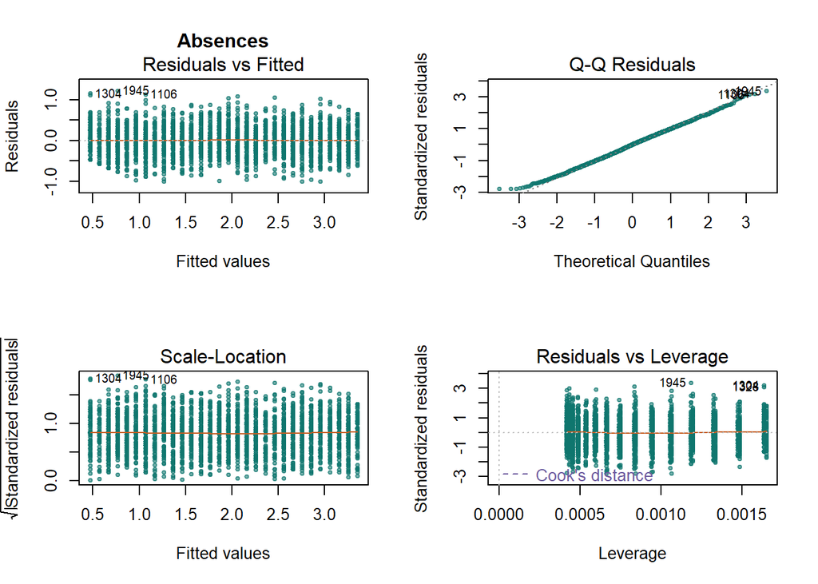

Figure 13: Combined diagnostic panel for the absences model.

```r
par(mfrow = c(2, 2))
plot(absence_model, which = 1,
     main = "Absences",
     col = adjustcolor(portfolio_teal, alpha.f = 0.58),
     panel = portfolio_panel,
     pch = 19, cex = 0.55, id.n = 3)
plot(absence_model, which = 2,
     col = adjustcolor(portfolio_teal, alpha.f = 0.58),
     panel = portfolio_panel,
     pch = 19, cex = 0.55, id.n = 3)
plot(absence_model, which = 3,
     col = adjustcolor(portfolio_teal, alpha.f = 0.58),
     panel = portfolio_panel,
     pch = 19, cex = 0.55, id.n = 3)
plot(absence_model, which = 5,
     col = adjustcolor(portfolio_teal, alpha.f = 0.58),
     panel = portfolio_panel,
     cook.col = portfolio_purple,
     pch = 19, cex = 0.55, id.n = 3)
par(mfrow = c(1, 1))
```

The study-time model shows more noticeable Q-Q tail departures and mild variation in residual spread. The absences model diagnostics appear more stable overall, although neither set of plots proves that all assumptions hold exactly.

## 6 Multiple Regression Model

### 6.1 Model Specification

The multiple regression combines two numerical predictors with tutoring, parental support, and extracurricular participation. The reference categories are no tutoring, no parental support, and no extracurricular participation.

**Show R code**

```r
student_data <- student_data %>%
  mutate(
    TutoringF = factor(Tutoring, levels = c(0, 1),
                       labels = c("No", "Yes")),
    ParentalSupportF = factor(ParentalSupport, levels = c(0, 1, 2, 3, 4),
                              labels = c("None", "Low", "Moderate",
                                         "High", "Very High")),
    ExtracurricularF = factor(Extracurricular, levels = c(0, 1),
                              labels = c("No", "Yes"))
  )
```

The retained predictors and reference levels are unchanged from the completed model. No interaction terms or transformations are added.

**Show R code**

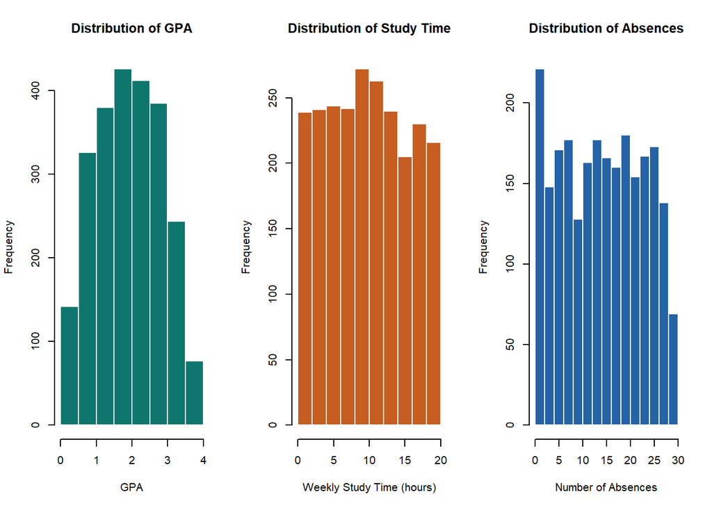

Figure 14: Distributions of GPA, weekly study time, and absences.

```r
par(mfrow = c(1, 3))

hist(student_data$GPA,
     main = "Distribution of GPA",
     xlab = "GPA",
     col  = portfolio_teal,
     border = "white")

hist(student_data$StudyTimeWeekly,
     main = "Distribution of Study Time",
     xlab = "Weekly Study Time (hours)",
     col  = portfolio_orange,
     border = "white")

hist(student_data$Absences,
     main = "Distribution of Absences",
     xlab = "Number of Absences",
     col  = portfolio_blue,
     border = "white")

par(mfrow = c(1, 1))
```

The predictor distributions are shown for context. Linear regression does not require predictors themselves to be Normally distributed. No transformations were used in the completed specification; the adequacy of the linear model is assessed primarily through residual diagnostics.

**Show R code**

```r
final_model <- lm(
  GPA ~ StudyTimeWeekly + Absences + TutoringF +
        ParentalSupportF + ExtracurricularF,
  data = student_data
)

summary(final_model)
```

```
Call:
lm(formula = GPA ~ StudyTimeWeekly + Absences + TutoringF + ParentalSupportF +
    ExtracurricularF, data = student_data)

Residuals:
     Min       1Q   Median       3Q      Max
-0.84642 -0.14857  0.00162  0.14437  0.71541

Coefficients:
                            Estimate Std. Error  t value Pr(>|t|)
(Intercept)                2.5934112  0.0195095  132.931   <2e-16 ***
StudyTimeWeekly            0.0291188  0.0008084   36.018   <2e-16 ***
Absences                  -0.0993746  0.0005389 -184.411   <2e-16 ***
TutoringFYes               0.2497705  0.0099451   25.115   <2e-16 ***
ParentalSupportFLow        0.1601161  0.0183583    8.722   <2e-16 ***
ParentalSupportFModerate   0.3056891  0.0173784   17.590   <2e-16 ***
ParentalSupportFHigh       0.4565770  0.0174990   26.092   <2e-16 ***
ParentalSupportFVery High  0.6206198  0.0207517   29.907   <2e-16 ***
ExtracurricularFYes        0.1871336  0.0093901   19.929   <2e-16 ***
---
Signif. codes:  0 '***' 0.001 '**' 0.01 '*' 0.05 '.' 0.1 ' ' 1

Residual standard error: 0.223 on 2383 degrees of freedom
Multiple R-squared:  0.9408,    Adjusted R-squared:  0.9406
F-statistic:  4734 on 8 and 2383 DF,  p-value: < 2.2e-16
```

## 7 Model Interpretation

The fitted multiple regression model is:

$$\widehat{\text{GPA}} = 2.593 + 0.029 \times \text{StudyTime}
- 0.099 \times \text{Absences}$$

$$+\ 0.250 \times \text{Tutoring}_{\text{Yes}}
+ 0.160 \times \text{PS}_{\text{Low}}
+ 0.306 \times \text{PS}_{\text{Moderate}}$$

$$+\ 0.457 \times \text{PS}_{\text{High}}
+ 0.621 \times \text{PS}_{\text{Very High}}
+ 0.187 \times \text{Extracurricular}_{\text{Yes}}$$

All reported coefficients have (p<2^{-16}). Each coefficient is interpreted as an adjusted in-sample association while holding the remaining included predictors constant:

- **Intercept : 2.5934112:** fitted GPA for the reference profile at zero study hours and zero absences. This baseline is mathematically required but may not represent a typical student.
- **Weekly study time : +0.0291188:** each additional weekly study hour is associated with an average GPA difference of approximately **+0.029 points**.
- **Absences : −0.0993746:** each additional absence is associated with an average GPA difference of approximately **−0.099 points**.
- **Tutoring : +0.2497705:** students receiving tutoring have an adjusted fitted GPA approximately **0.250 points** higher than students not receiving tutoring.
- **Parental support:** relative to no parental support, the adjusted fitted differences are approximately **+0.160** for Low, **+0.306** for Moderate, **+0.457** for High, and **+0.621** for Very High support.
- **Extracurricular participation : +0.1871336:** participating students have an adjusted fitted GPA approximately **0.187 points** higher than non-participating students.

These coefficients quantify conditional associations within the analysed data. They do not establish causal effects.

### 7.1 Model Fit

**Show R code**

```r
final_model_fit <- glance(final_model) %>%
  select(r.squared, adj.r.squared, sigma, statistic, p.value)

kable(final_model_fit, digits = 4,
      caption = "In-Sample Fit Statistics for the Multiple Regression Model",
      col.names = c("R²", "Adjusted R²", "Residual SE", "F Statistic", "p-value")) %>%
  kable_styling(full_width = FALSE)
```

In-Sample Fit Statistics for the Multiple Regression Model

| R² | Adjusted R² | Residual SE | F Statistic | p-value |
| --- | --- | --- | --- | --- |
| 0.9408 | 0.9406 | 0.223 | 4733.538 | 0 |

The model has (R^2=0.9408), adjusted (R^2=0.9406), residual standard error **0.2230**, and (F(8,2383)=4734) with (p<2.2^{-16}). Together, the included predictors explain approximately **94.1%** of observed GPA variation in sample.

## 8 Regression Diagnostics

**Show R code**

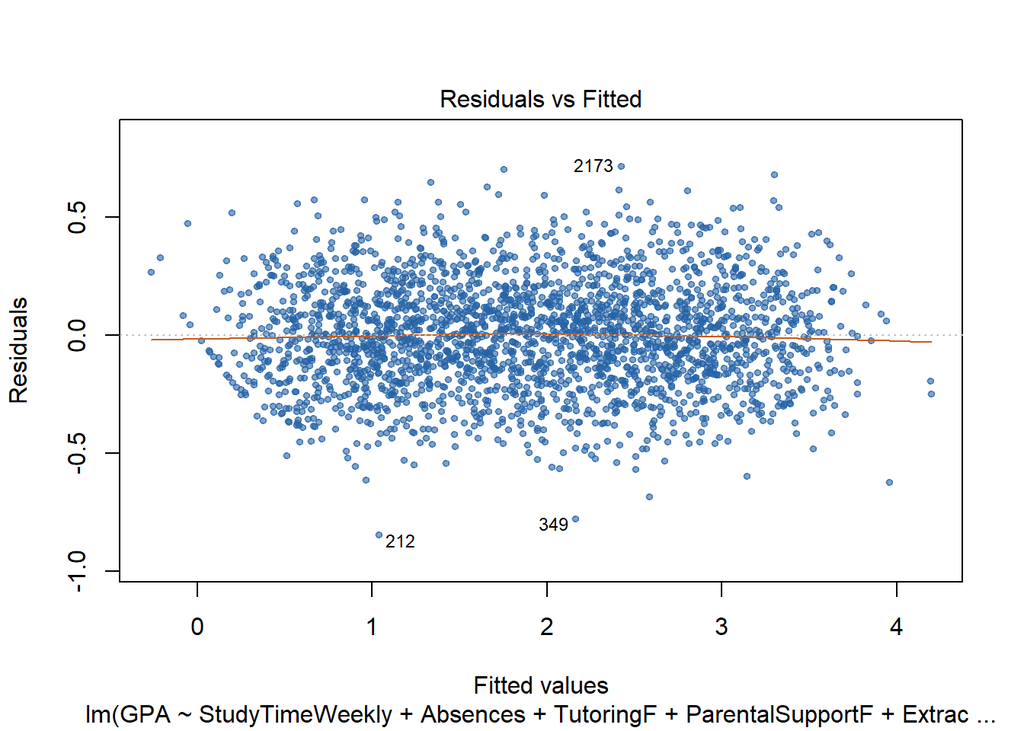

Figure 15: Residuals versus fitted values for the multiple regression model.

```r
plot(final_model, which = 1,
     col = adjustcolor(portfolio_blue, alpha.f = 0.58),
     panel = portfolio_panel,
     pch = 19, cex = 0.65, id.n = 3)
```

The residual smoother is broadly horizontal. This is consistent with an approximately linear conditional mean, while small local departures may remain.

**Show R code**

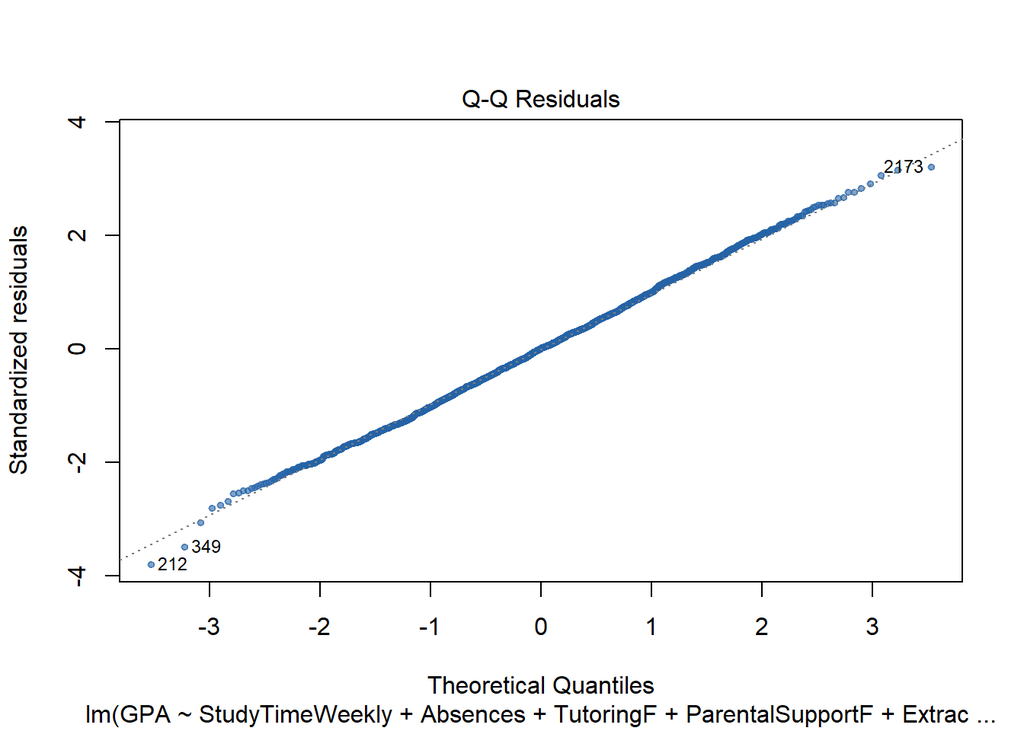

Figure 16: Normal Q-Q plot of residuals from the multiple regression model.

```r
plot(final_model, which = 2,
     col = adjustcolor(portfolio_blue, alpha.f = 0.58),
     panel = portfolio_panel,
     pch = 19, cex = 0.65, id.n = 3)
```

Residuals track the reference line through most of the distribution, with departures in the tails. The plot supports approximate rather than exact residual Normality.

**Show R code**

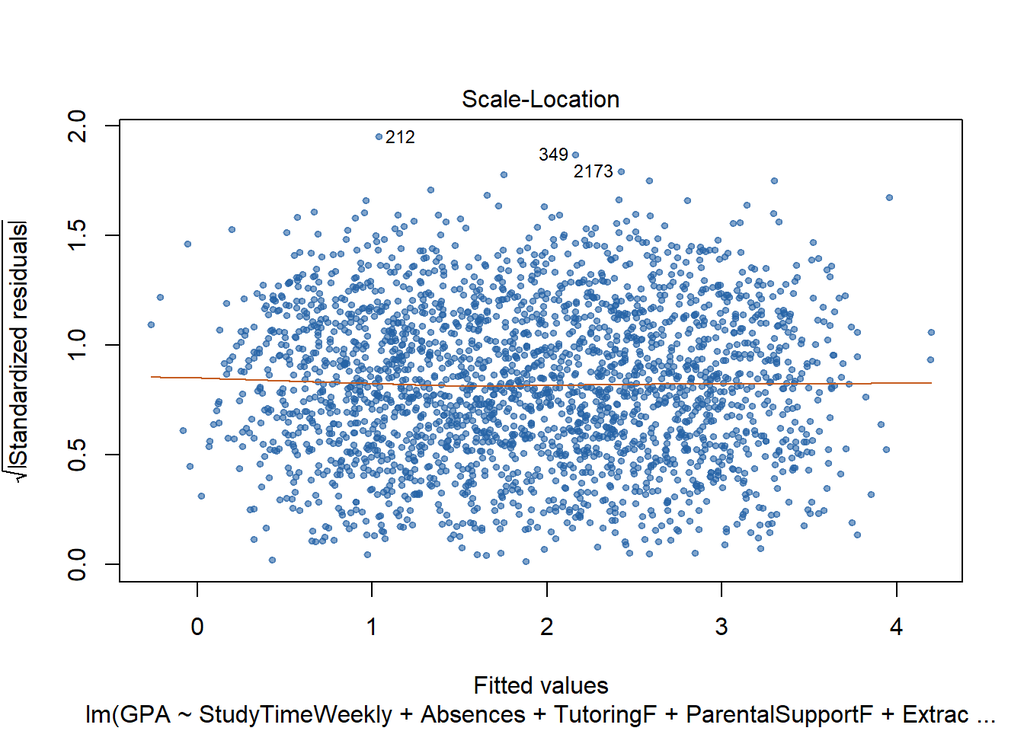

Figure 17: Scale-location diagnostic for the multiple regression model.

```r
plot(final_model, which = 3,
     col = adjustcolor(portfolio_blue, alpha.f = 0.58),
     panel = portfolio_panel,
     pch = 19, cex = 0.65, id.n = 3)
```

The scale-location plot indicates broadly stable residual spread, although visual diagnostics cannot establish perfectly constant variance.

**Show R code**

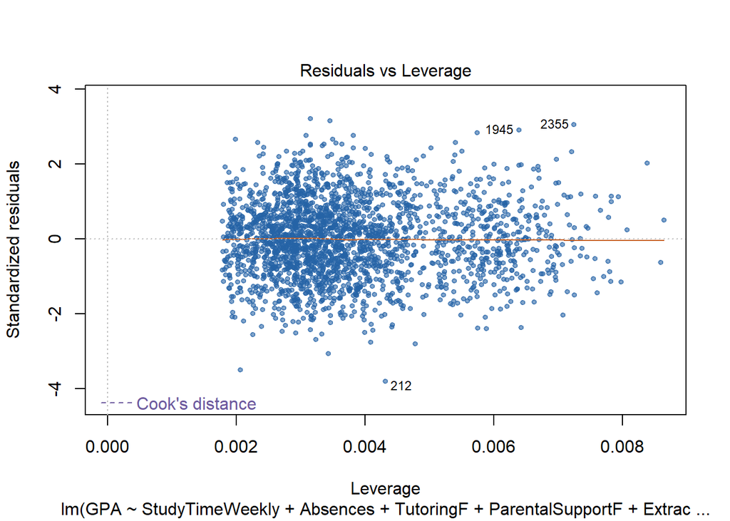

Figure 18: Residuals versus leverage for the multiple regression model.

```r
plot(final_model, which = 5,
     col = adjustcolor(portfolio_blue, alpha.f = 0.58),
     panel = portfolio_panel,
     cook.col = portfolio_purple,
     pch = 19, cex = 0.65, id.n = 3)
```

No observations are displayed beyond the Cook’s-distance contours. This provides no clear evidence that a single record dominates the fitted results, but it is not a guarantee that influence is absent.

Independence remains an adopted assumption because the sampling structure is unknown. The diagnostics are broadly consistent with the fitted specification, subject to the limitations of visual assessment and the bounded GPA response.

### 8.1 Fitted Versus Observed GPA

**Show R code**

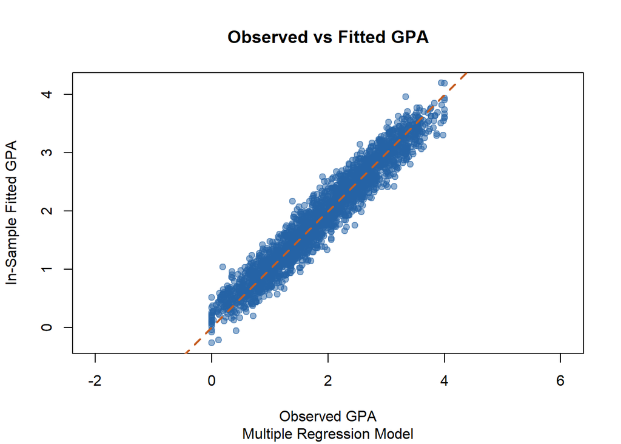

Figure 19: Observed GPA versus in-sample fitted GPA for the multiple regression model.

```r
predicted_gpa <- predict(final_model)

plot(student_data$GPA, predicted_gpa,
     main = "Observed vs Fitted GPA",
     sub  = "Multiple Regression Model",
     xlab = "Observed GPA",
     ylab = "In-Sample Fitted GPA",
     pch  = 19,
     col = adjustcolor(portfolio_blue, alpha.f = 0.5),
     asp = 1)

abline(a = 0, b = 1, col = portfolio_orange, lwd = 2, lty = 2)
```

The fitted values are close to the 45-degree reference line for much of the observed range. Because these are in-sample fitted values, the plot assesses model fit rather than performance on new students.

## 9 Comparative In-Sample Performance

**Show R code**

```r
study_model_fit2   <- glance(study_model)   %>% mutate(Model = "GPA ~ Study Time")
absence_model_fit2 <- glance(absence_model) %>% mutate(Model = "GPA ~ Absences")
final_model_fit2   <- glance(final_model)   %>% mutate(Model = "GPA ~ All Predictors")

comparison_table <- bind_rows(
  study_model_fit2,
  absence_model_fit2,
  final_model_fit2
) %>%
  select(Model, r.squared, adj.r.squared, sigma, statistic, p.value) %>%
  rename(
    `R²`      = r.squared,
    `Adjusted R²` = adj.r.squared,
    `Residual SE` = sigma,
    `F Statistic` = statistic,
    `p-value` = p.value
  ) %>%
  mutate(`p-value` = format.pval(`p-value`, digits = 4, eps = 0.0001))

kable(comparison_table, digits = 3,
      caption = "In-Sample Comparison of GPA Regression Models") %>%
  kable_styling(full_width = FALSE, position = "center")
```

In-Sample Comparison of GPA Regression Models

| Model | R² | Adjusted R² | Residual SE | F Statistic | p-value |
| --- | --- | --- | --- | --- | --- |
| GPA ~ Study Time | 0.032 | 0.032 | 0.901 | 79.364 | < 1e-04 |
| GPA ~ Absences | 0.845 | 0.845 | 0.360 | 13043.041 | < 1e-04 |
| GPA ~ All Predictors | 0.941 | 0.941 | 0.223 | 4733.538 | < 1e-04 |

**Show R code**

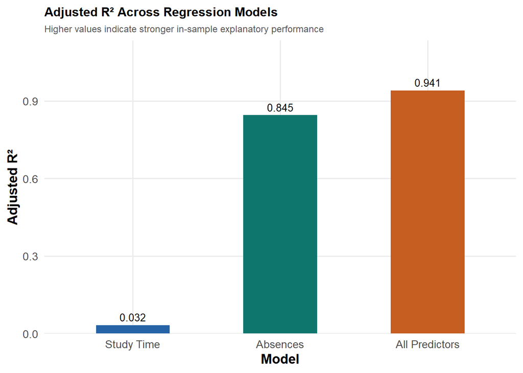

Figure 20: Adjusted R-squared comparison across the three fitted regression models.

```r
comparison_plot_data <- bind_rows(
  glance(study_model)   %>% mutate(Model = "Study Time"),
  glance(absence_model) %>% mutate(Model = "Absences"),
  glance(final_model)   %>% mutate(Model = "All Predictors")
) %>%
  select(Model, adj.r.squared)

ggplot(comparison_plot_data,
       aes(x = reorder(Model, adj.r.squared),
           y = adj.r.squared, fill = Model)) +
  geom_col(width = 0.5) +
  geom_text(aes(label = round(adj.r.squared, 3)),
            vjust = -0.5, size = 3.5) +
  scale_y_continuous(
    limits = c(0, 1.05),
    expand = expansion(mult = c(0, 0.08))
  ) +
  scale_fill_manual(values = c(portfolio_teal, portfolio_orange, portfolio_blue)) +
  labs(
    title    = "Adjusted R² Across Regression Models",
    subtitle = "Higher values indicate stronger in-sample explanatory performance",
    x = "Model",
    y = "Adjusted R²"
  ) +
  theme_minimal(base_size = 13) +
  theme(
    plot.title      = element_text(face = "bold", size = 12),
    plot.subtitle   = element_text(size = 9, colour = "gray35"),
    axis.title      = element_text(face = "bold"),
    legend.position = "none",
    panel.grid.minor = element_blank()
  )
```

The multiple regression has the highest adjusted (R^2) and lowest residual standard error of the three specifications. Relative to the absences-only model, adjusted (R^2) increases from approximately **0.845** to **0.941**, while residual standard error decreases from approximately **0.360** to **0.223**.

These results establish stronger in-sample explanatory performance for the multiple regression. They do not establish that it is the best possible model or that it will provide equally strong predictions for unseen data.

## 10 Key Findings

- Weekly study time is positively associated with GPA, but the simple model explains only approximately **3.2%** of observed GPA variation.
- Absences are strongly negatively associated with GPA, and the simple model explains approximately **84.5%** of observed variation.
- The multiple regression has (R^2=0.9408), adjusted (R^2=0.9406), and residual standard error **0.2230**.
- All coefficients in the multiple regression are statistically significant at the 5% level.
- Conditional on the other included predictors, study time, tutoring, parental support, and extracurricular participation have positive fitted associations with GPA, while absences have a negative fitted association.
- Diagnostic plots are broadly consistent with the regression assumptions, with some tail departures and mild variation in residual behaviour.
- All model comparisons are in sample and do not quantify performance for new students.

## 11 Limitations

The data are observational, so regression coefficients describe associations and cannot establish causation. Omitted variables and other confounding factors may contribute to the reported relationships. The sampling design is not documented, limiting assessment of independence and generalisability.

GPA is bounded between 0 and 4, while ordinary linear regression is unbounded. The models may therefore produce implausible fitted or extrapolated values, particularly near the scale boundaries. Linearity, constant variance, residual Normality, and independence are modelling assumptions that are only partly assessable through the available diagnostics.

Model evaluation is entirely in sample. No train/test split, cross-validation, holdout evaluation, or external validation was performed. Consequently, (R^2), adjusted (R^2), residual standard error, and observed-versus-fitted plots should not be interpreted as estimates of future predictive performance.

The final predictor specification is retained from the completed analysis. This report does not evaluate alternative model-selection strategies, interactions, nonlinear relationships, or model forms designed specifically for bounded outcomes.